# Project 5 - Title

### Exploratory Data Analysis

**Number of Datapoints**

```r
# Number of rows
nb_rows <- nrow(dataset)
```

We have access to 300k datapoints.

**Prediction Variable**  
Let’s first analyse the prediction variable alone.

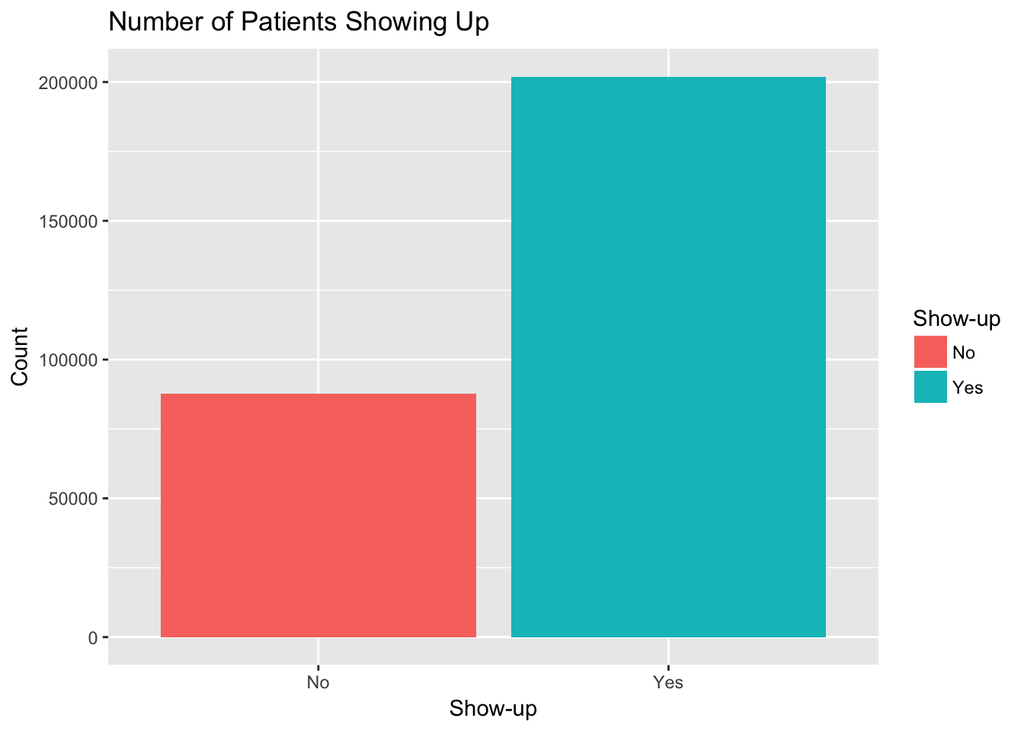

```r
ggplot(dataset, aes(x = show_up, fill=show_up)) +
  geom_bar() +
  ggtitle("Number of Patients Showing Up") +
  ylab("Count") +
  xlab("Show-up") +
  scale_fill_discrete("Show-up", labels=c("No", "Yes")) +
  scale_x_discrete(labels=c("No", "Yes"))
```

On the 300k datapoints we have, one third of them are No-Show Datapoints.  
From a data science point of view, we have unbalanced classes, we will have to deal with it when doing predictions.

**Timeframe & Number of Datapoints per Day**

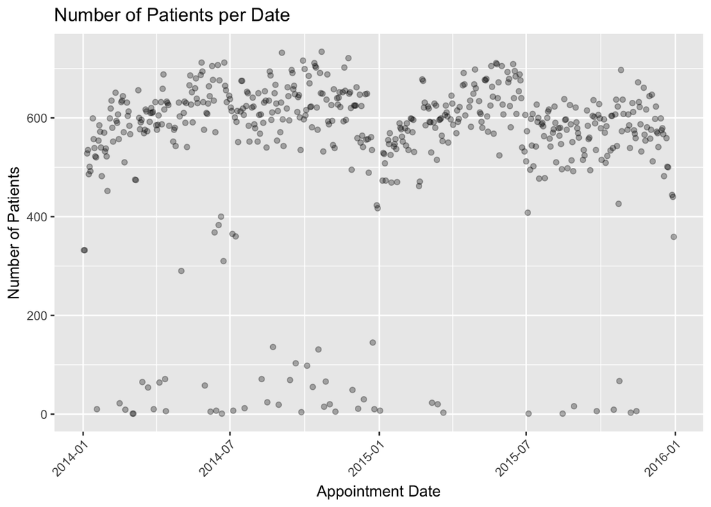

```r
dataset %>%
  group_by(appointment_date) %>%
  summarise(patients=n()) %>%
  ggplot(aes(x=appointment_date, y=patients)) +
    geom_point(alpha=0.3) +
    xlab("Appointment Date") +
    ylab("Number of Patients") +
    ggtitle("Number of Patients per Date") +
    theme(axis.text.x = element_text(angle = 45, hjust = 1))
```

**Gender Analysis**

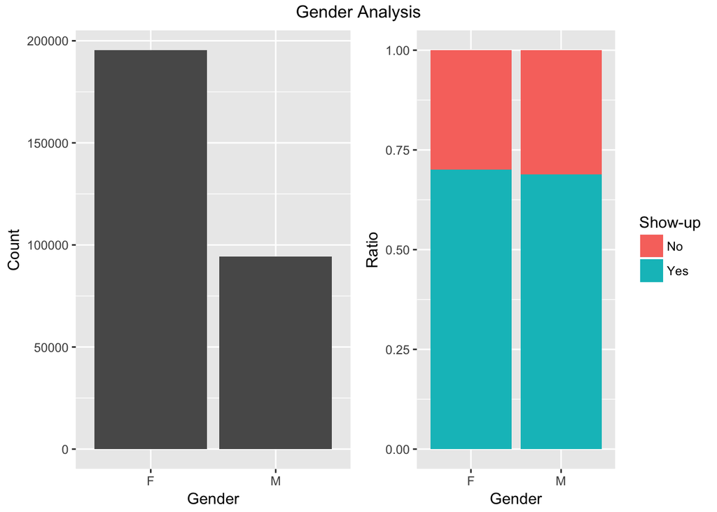

```r
gender_number <- ggplot(dataset, aes(x=gender)) +
  geom_bar() +
  xlab("Gender") +
  ylab("Count")

gender_ratio <- ggplot(dataset, aes(x=gender, fill=show_up)) +
  geom_bar(position="fill") +
  xlab("Gender") +
  ylab("Ratio") +
  scale_fill_discrete("Show-up", labels=c("No", "Yes"))

grid.arrange(gender_number, gender_ratio, ncol=2, top="Gender Analysis")
```

The first insight is that women are more often going to visit a physician. However the ration of no-show/show are realyy similar. Gender doesn’t seem to play an important role.

**Age Analysis**

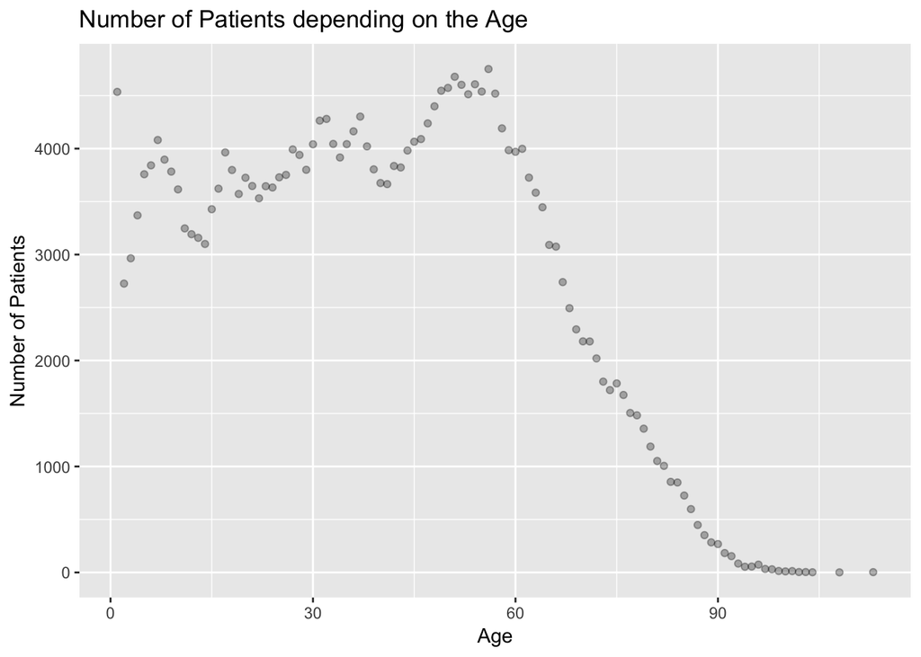

```r
dataset %>%
  group_by(age) %>%
  summarise(nb_perage=n()) %>%
  ggplot(aes(x=age, y=nb_perage)) +
    geom_point(alpha=0.3) +
    xlab("Age") +
    ylab("Number of Patients") +
    ggtitle("Number of Patients depending on the Age")
```

On the first graph, we display the number of patient depending on the age to know what the sample we have look like. After 60 years old, people begin to die, and hence there are less patients. We see on the representation of the ife expectancy of people in Brazil whicih is comprised between 60 and 100 years old. (The life expectancy in Brazil is 73.8 years old).

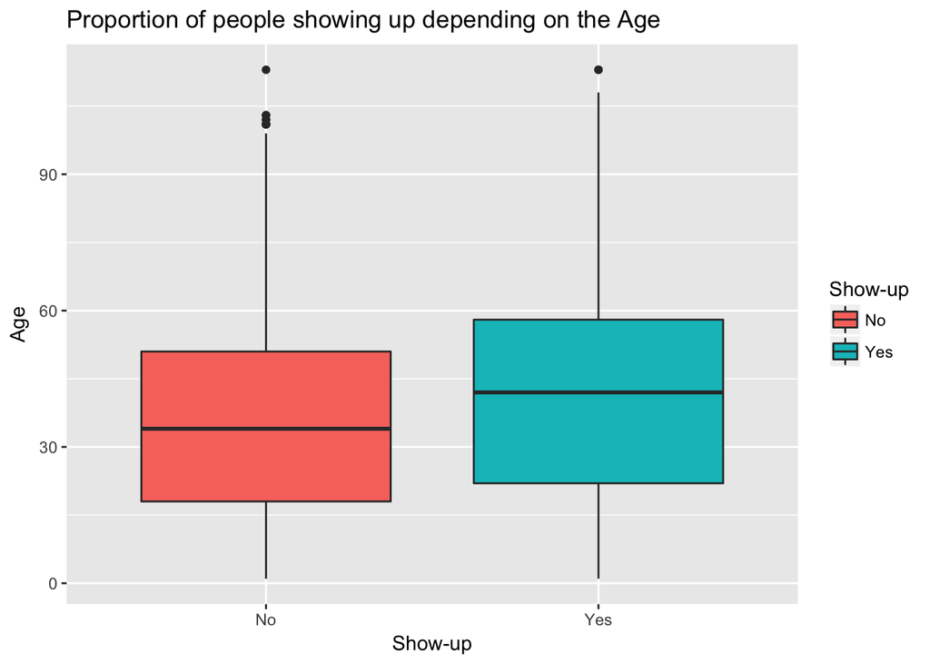

```r
ggplot(dataset, aes(x=show_up, y=age, fill=show_up)) +
  geom_boxplot() +
  xlab("Show-up") +
  ylab("Age") +
  ggtitle("Proportion of people showing up depending on the Age") +
  scale_fill_discrete("Show-up", labels=c("No", "Yes")) +
  scale_x_discrete(labels=c("No", "Yes"))
```

The age seems to be a important factor. The older the people are the more likely they are going to show up.

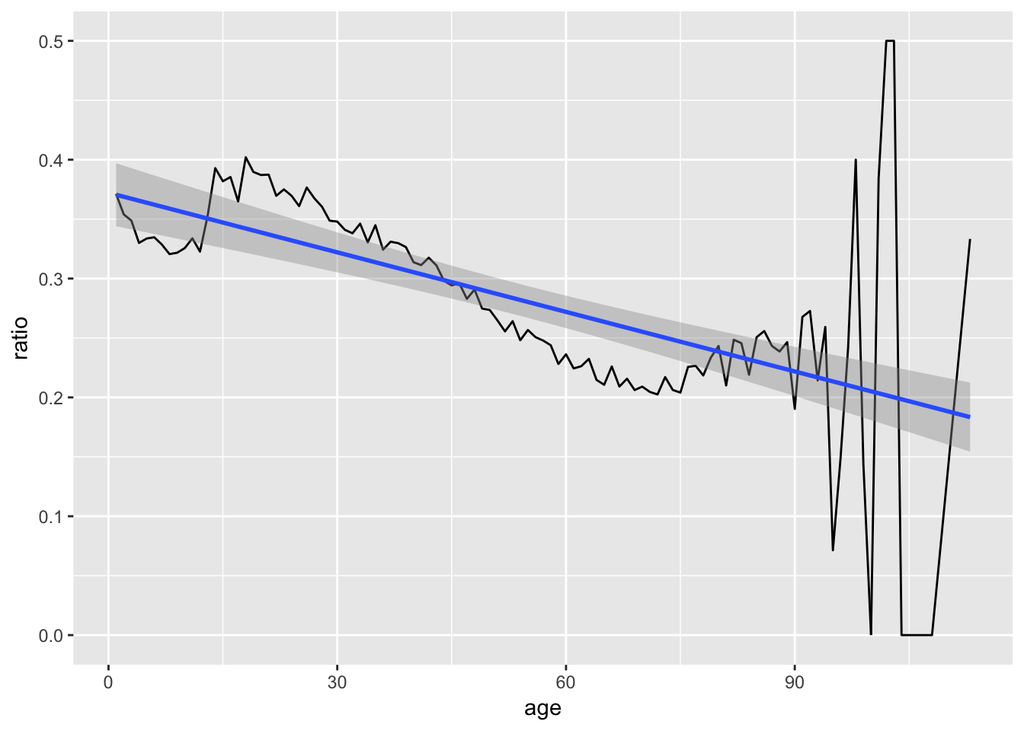

```r
by_age <-
  dataset %>%
    group_by(age) %>%
    summarise(show = sum(show_up==1), noshow = sum(show_up == 0))
by_age$ratio = by_age$noshow / (by_age$show+by_age$noshow)

ggplot(data = by_age, aes(x = age, y = ratio)) +
  geom_line() +
  geom_smooth(method = "glm")
```

Above, we can see the same trend. After 95 years old the figures are not significant because the sample is too small. Hence only the first part of the graph can be interpreted.

**Age & Gender Analysis**

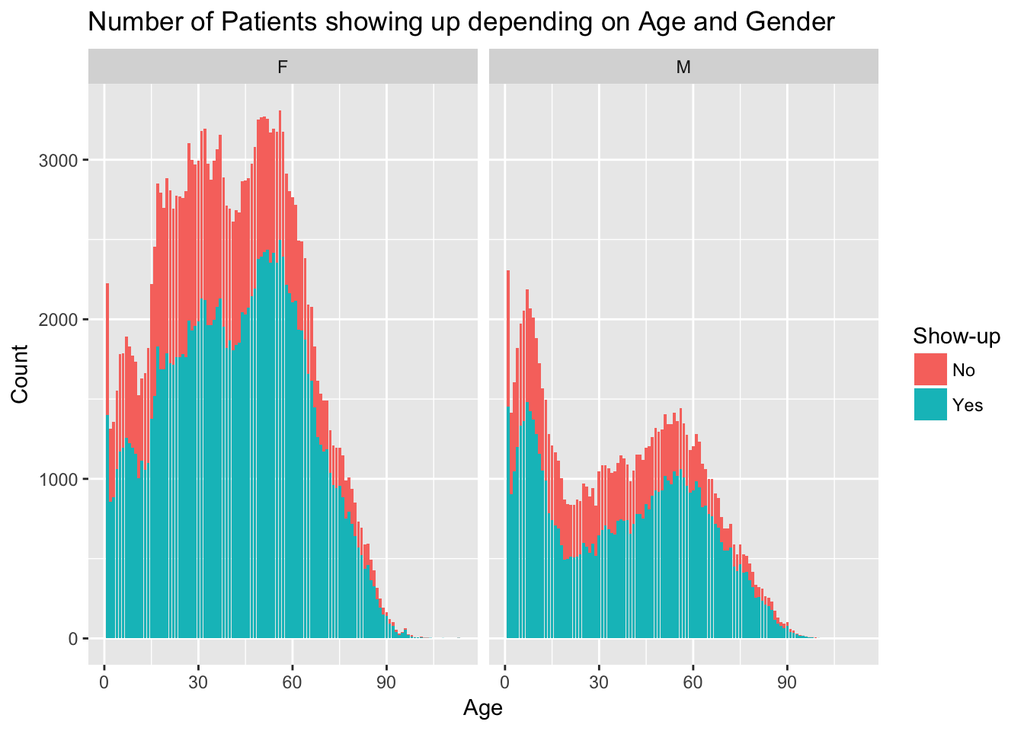

```r
ggplot(data = dataset, aes(x = age, fill = show_up)) +
  geom_bar() +
  facet_wrap(~gender) +
  xlab("Age") +
  ylab("Count") +
  ggtitle("Number of Patients showing up depending on Age and Gender") +
  scale_fill_discrete("Show-up", labels=c("No", "Yes"))
```

The ratio is similar between woman and man. We see again that women take more appointments. However we see that before 20 years old the numbe rof appointments and the trend is exactly the same.

**Health Conditions Analysis**

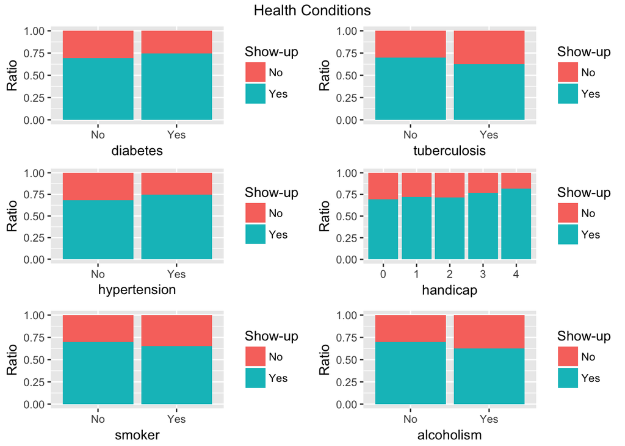

```r
diabetes <- ggplot(dataset, aes(x=diabetes, fill=show_up)) +
  geom_bar(position="fill") +
  ylab("Ratio") +
  scale_x_discrete(labels=c("No", "Yes")) +
  scale_fill_discrete("Show-up", labels=c("No", "Yes"))
alcoholism <- ggplot(dataset, aes(x=alcoholism, fill=show_up)) +
  geom_bar(position="fill") +
  ylab("Ratio") +
  scale_x_discrete(labels=c("No", "Yes")) +
  scale_fill_discrete("Show-up", labels=c("No", "Yes"))
hypertension <- ggplot(dataset, aes(x=hypertension, fill=show_up)) +
  geom_bar(position="fill") +
  ylab("Ratio") +
  scale_x_discrete(labels=c("No", "Yes")) +
  scale_fill_discrete("Show-up", labels=c("No", "Yes"))
handicap <- ggplot(dataset, aes(x=handicap, fill=show_up)) +
  geom_bar(position="fill") +
  ylab("Ratio") +
  scale_fill_discrete("Show-up", labels=c("No", "Yes"))
smoker <- ggplot(dataset, aes(x=smoker, fill=show_up)) +
  geom_bar(position="fill") +
  ylab("Ratio") +
  scale_x_discrete(labels=c("No", "Yes")) +
  scale_fill_discrete("Show-up", labels=c("No", "Yes"))
tuberculosis <- ggplot(dataset, aes(x=tuberculosis, fill=show_up)) +
  geom_bar(position="fill") +
  ylab("Ratio") +
  scale_x_discrete(labels=c("No", "Yes")) +
  scale_fill_discrete("Show-up", labels=c("No", "Yes"))

grid.arrange(diabetes, tuberculosis, hypertension, handicap, smoker,
             alcoholism, ncol=2, top='Health Conditions')
```

Form this first anaysis, we can conclude that people having a handicap are more likely to show up, going further the more severe is there handicap the more likely they are going to show up. The same trand is observed for people havnig diabete or hypertension.  
However for smokers, alcoholic people and people suffering from tuberculosis, the trend is reverse.  
To validate this insights, we need to look at the samples size, which we are going to do below.

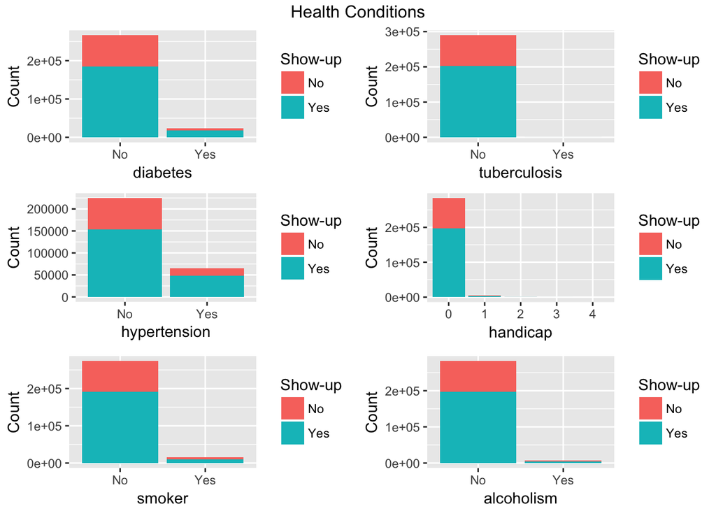

```r
diabetes <- ggplot(dataset, aes(x=diabetes, fill=show_up)) +
  geom_bar() +
  ylab("Count") +
  scale_x_discrete(labels=c("No", "Yes")) +
  scale_fill_discrete("Show-up", labels=c("No", "Yes"))
alcoholism <- ggplot(dataset, aes(x=alcoholism, fill=show_up)) +
  geom_bar() +
  ylab("Count") +
  scale_x_discrete(labels=c("No", "Yes")) +
  scale_fill_discrete("Show-up", labels=c("No", "Yes"))
hypertension <- ggplot(dataset, aes(x=hypertension, fill=show_up)) +
  geom_bar() +
  ylab("Count") +
  scale_x_discrete(labels=c("No", "Yes")) +
  scale_fill_discrete("Show-up", labels=c("No", "Yes"))
handicap <- ggplot(dataset, aes(x=handicap, fill=show_up)) +
  geom_bar() +
  ylab("Count") +
  scale_fill_discrete("Show-up", labels=c("No", "Yes"))
smoker <- ggplot(dataset, aes(x=smoker, fill=show_up)) +
  geom_bar() +
  ylab("Count") +
  scale_x_discrete(labels=c("No", "Yes")) +
  scale_fill_discrete("Show-up", labels=c("No", "Yes"))
tuberculosis <- ggplot(dataset, aes(x=tuberculosis, fill=show_up)) +
  geom_bar() +
  ylab("Count") +
  scale_x_discrete(labels=c("No", "Yes")) +
  scale_fill_discrete("Show-up", labels=c("No", "Yes"))

grid.arrange(diabetes, tuberculosis, hypertension, handicap, smoker,
             alcoholism, ncol=2, top='Health Conditions')
```

As we were expected, we always have less sick people. The number of people having tuberculosis is so low that the ratio we analyzed earlier should not to be taken into account.

**SMS Reminder**

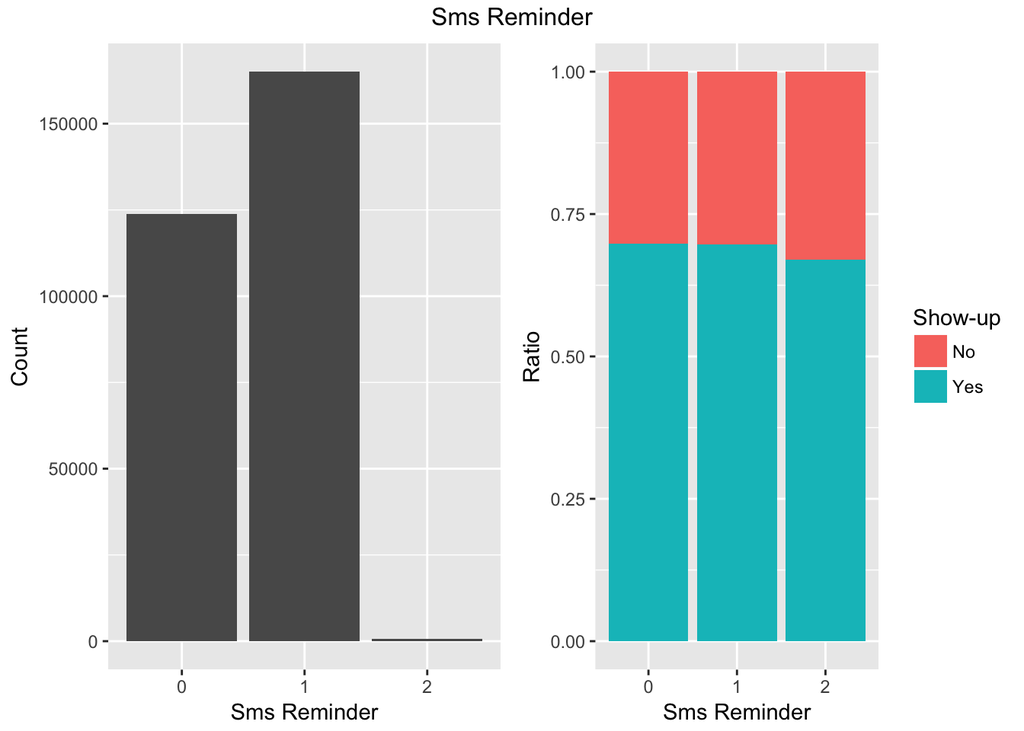

```r
smsreminder_number <- ggplot(dataset, aes(x=sms_reminder)) +
  geom_bar() +
  xlab("Sms Reminder") +
  ylab("Count")

smsreminder_ratio <- ggplot(dataset, aes(x=sms_reminder, fill=show_up)) +
  geom_bar(position="fill") +
  xlab("Sms Reminder") +
  ylab("Ratio") +
  scale_fill_discrete("Show-up", labels=c("No", "Yes"))

grid.arrange(smsreminder_number, smsreminder_ratio, ncol=2, top="Sms Reminder")
```

There is no strong pattern associated with the sending of a sms reminder. Without taking into account people that received 2 sms (too few people), we notice that the ration is really similar. However we don’t know if those sms are sent randomnly or not.

**Scholarship Analysis**

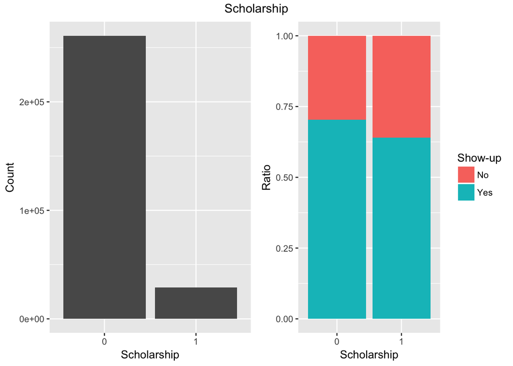

```r
smsreminder_number <- ggplot(dataset, aes(x=scholarship)) +
  geom_bar() +
  xlab("Scholarship") +
  ylab("Count")

smsreminder_ratio <- ggplot(dataset, aes(x=scholarship, fill=show_up)) +
  geom_bar(position="fill") +
  xlab("Scholarship") +
  ylab("Ratio") +
  scale_fill_discrete("Show-up", labels=c("No", "Yes"))

grid.arrange(smsreminder_number, smsreminder_ratio, ncol=2, top="Scholarship")
```

We did explain at the beginning of this file what scholarship meant, it’s basically linked to the level of income of the family. We see that this feature have a strong impact.

**Time Analysis**

Overview of the dataset per date.

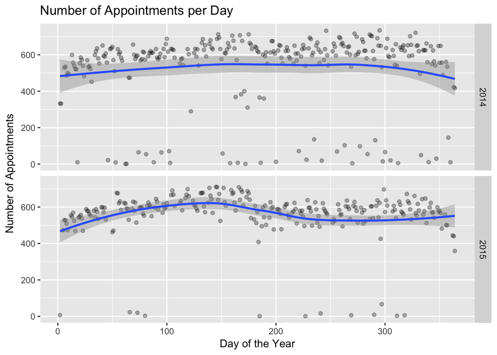

```r
dataset$year_appointment <- as.numeric(format(dataset$appointment_date,"%Y"))

dataset %>%
  group_by(day_of_year_appointment, year_appointment) %>%
  summarise(patients=n()) %>%
  ggplot(aes(x=day_of_year_appointment, y=patients)) +
    geom_point(alpha=0.3) +
    geom_smooth(method = 'loess') +
    facet_grid(year_appointment ~ .) +
    xlab("Day of the Year") +
    ylab("Number of Appointments") +
    ggtitle("Number of Appointments per Day")
```

We observe a very small trend: people schedule slightly more medical appointment during the first half of the year.

Now, to explain a little bit how time influences our variable of interest, we show the evolution of the noshow ratio through the period we are studying.

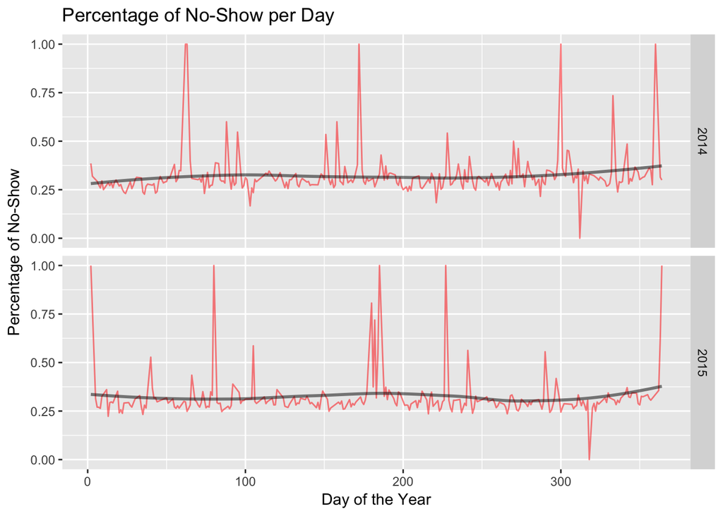

```r
dataset %>%
  group_by(day_of_year_appointment, year_appointment) %>%
  summarise(total_noshow=sum(show_up==0)/n()) %>%
  ggplot(aes(x=day_of_year_appointment, y=total_noshow)) +
    geom_line(alpha=0.5, color = "red") +
    geom_smooth(method = 'loess', se = FALSE, color = alpha('black',0.5)) +
    facet_grid(year_appointment ~ .) +
    xlab("Day of the Year") +
    ylim(0,1) +
    ylab("Percentage of No-Show") +
    ggtitle("Percentage of No-Show per Day")
```

Using a daily granularity, we observe a high variance that makes the graph difficult to interpret. Let’s change modify the graph by using a weekly granularity.

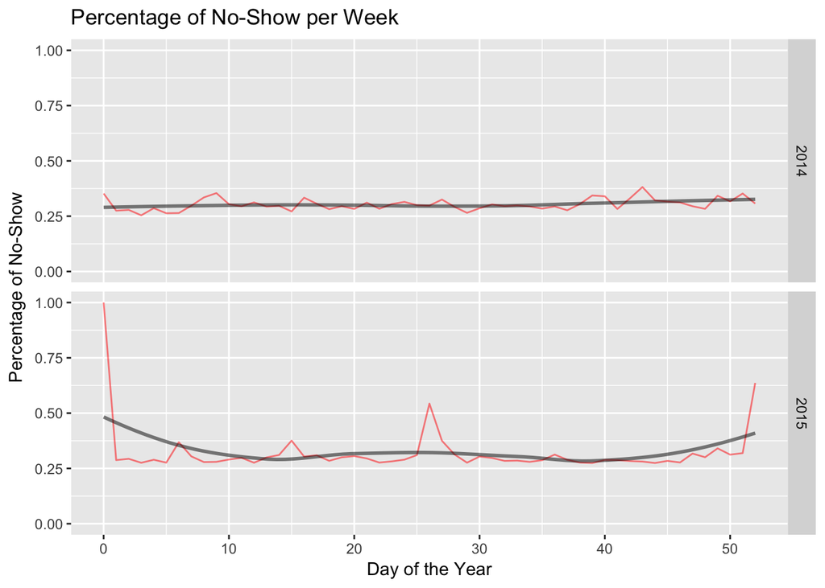

```r
dataset %>%
  group_by(week_of_year_appointment, year_appointment) %>%
  summarise(total_noshow=sum(show_up==0)/n()) %>%
  ggplot(aes(x=week_of_year_appointment, y=total_noshow)) +
    geom_line(alpha=0.5, color = "red") +
    geom_smooth(method = 'loess', se = FALSE, color = alpha('black',0.5)) +
    facet_grid(year_appointment ~ .) +
    xlab("Day of the Year") +
    ylim(0,1) +
    ylab("Percentage of No-Show") +
    ggtitle("Percentage of No-Show per Week")
```

On a weekly basis we have more or less the same observations: we don’t see any correlation between the date and the no-show ratio having a year window.

The natural next step is to look at the same ratio vs weekdays. It sounds pretty intuitive that there are some information to extract.

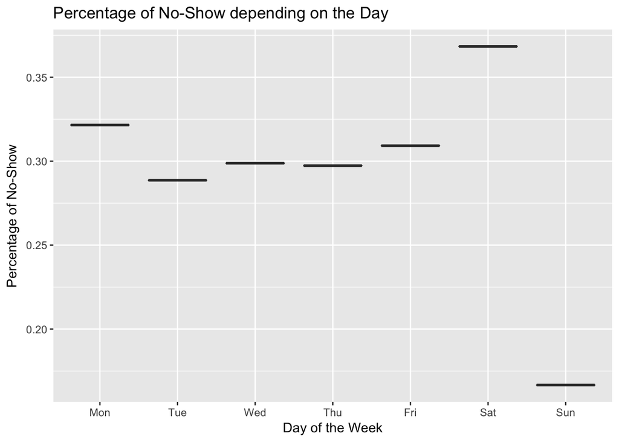

```r
by_day_of_week = group_by(dataset, weekday_appointment)
by_day = summarise(by_day_of_week,
                   show = sum(show_up == 1),
                   noshow = sum(show_up == 0))
by_day$ratio = by_day$noshow / (by_day$show+ by_day$noshow)
by_day$weekday_appointment = relevel(by_day$weekday_appointment, "Sun")
by_day$weekday_appointment = relevel(by_day$weekday_appointment, "Sat")
by_day$weekday_appointment = relevel(by_day$weekday_appointment, "Fri")
by_day$weekday_appointment = relevel(by_day$weekday_appointment, "Thu")
by_day$weekday_appointment = relevel(by_day$weekday_appointment, "Wed")
by_day$weekday_appointment = relevel(by_day$weekday_appointment, "Tue")
by_day$weekday_appointment = relevel(by_day$weekday_appointment, "Mon")

qplot(weekday_appointment, ratio, data = by_day,
      geom = c("boxplot"),
      xlab = "Day of the Week",
      ylab = "Percentage of No-Show",
      main = "Percentage of No-Show depending on the Day")
```

We clearly see a trend here: the ratio is extremely high on Saturday! It jumps from 30 to 37%. Sunday is not significant because very few people have appointment on Sundays.

Let us have a look ot the moment in the day the patient register for the appointment.

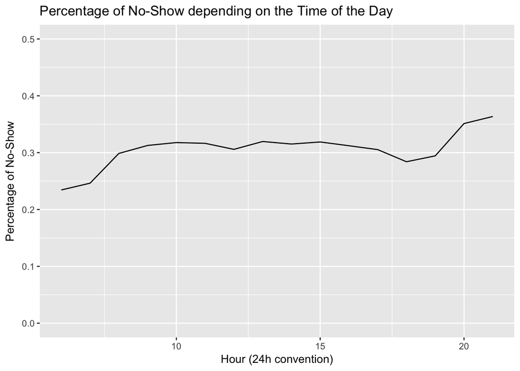

```r
by_hour <- group_by(dataset, hour_registration)
by_hour <- summarise(by_hour,
                     show=sum(show_up==1),
                     noshow=sum(show_up == 0))
by_hour$ratio <- by_hour$noshow / (by_hour$show+ by_hour$noshow)

ggplot(data=by_hour[by_hour$hour_registration>5,][by_hour$hour_registration<21,],
       aes(x = hour_registration, y = ratio)) +
  geom_line() +
  ylim(0,0.5) +
  xlab("Hour (24h convention)") +
  ylab("Percentage of No-Show") +
  ggtitle("Percentage of No-Show depending on the Time of the Day")
```

Another important aspect in the time dimention is the time difference between the moment they register for the appointment and the appointment date.

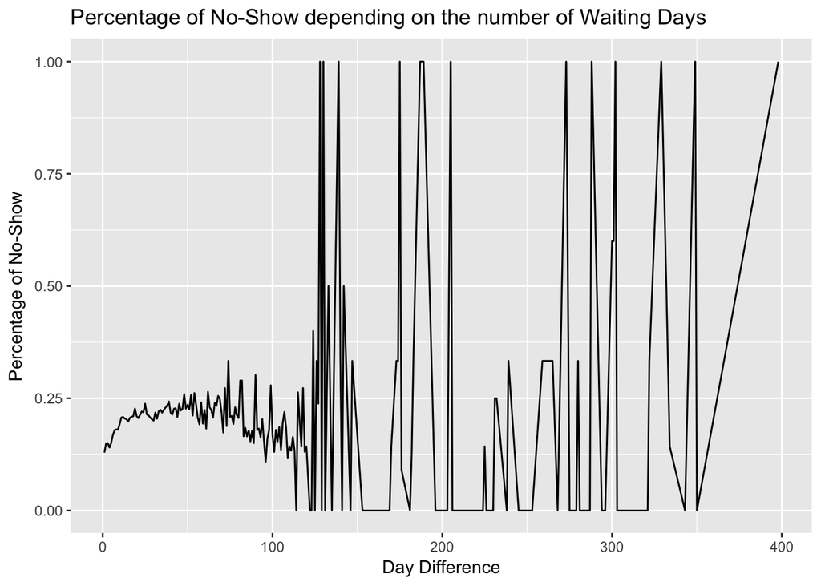

```r
by_diff <- group_by(dataset, daydiff_regist_appt)
by_diff <- summarise(by_diff,
                     show=sum(as.numeric(show_up)),
                     noshow=sum(show_up == 0))
by_diff$ratio <- by_diff$noshow / by_diff$show

ggplot(data = by_diff, aes(x = daydiff_regist_appt, y = ratio)) +
  geom_line() +
  xlab("Day Difference") +
  ylab("Percentage of No-Show") +
  ggtitle("Percentage of No-Show depending on the number of Waiting Days")
```

We first notice that the curve is extremely heratic after a certain value due to the number of datapoints. Let us zoom in the 0-120 days window. A waiting time of more than 120 days is really rare, so the second part od the curve isn’t significant.

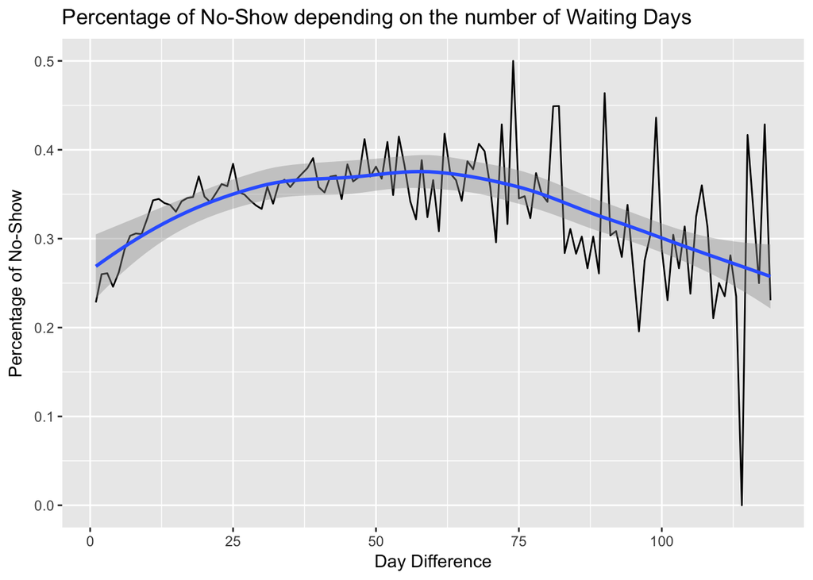

```r
by_diff <- group_by(dataset, daydiff_regist_appt)
by_diff <- summarise(by_diff,
                     show = sum(show_up==1),
                     noshow = sum(show_up == 0))
by_diff$ratio <- by_diff$noshow / (by_diff$show+by_diff$noshow)
by_diff$daydiff_regist_appt_squared <- by_diff$daydiff_regist_appt**2

ggplot(data = by_diff[by_diff$daydiff_regist_appt<120,],
       aes(x = daydiff_regist_appt, y = ratio)) +
  geom_line() +
  geom_smooth(method = 'loess') +
  xlab("Day Difference") +
  ylab("Percentage of No-Show") +
  ggtitle("Percentage of No-Show depending on the number of Waiting Days")
```

It seems that we have a good model using a polynomial regression as follow:

```r
summary(lm(ratio~daydiff_regist_appt + daydiff_regist_appt_squared, by_diff[by_diff$daydiff_regist_appt<120,]))
```

```
##
## Call:
## lm(formula = ratio ~ daydiff_regist_appt + daydiff_regist_appt_squared,
##     data = by_diff[by_diff$daydiff_regist_appt < 120, ])
##
## Residuals:
##       Min        1Q    Median        3Q       Max
## -0.257712 -0.026016 -0.000109  0.016365  0.186608
##
## Coefficients:
##                               Estimate Std. Error t value Pr(>|t|)
## (Intercept)                  2.807e-01  1.491e-02  18.834  < 2e-16 ***
## daydiff_regist_appt          3.407e-03  5.734e-04   5.941 3.04e-08 ***
## daydiff_regist_appt_squared -3.165e-05  4.629e-06  -6.838 3.99e-10 ***
## ---
## Signif. codes:  0 '***' 0.001 '**' 0.01 '*' 0.05 '.' 0.1 ' ' 1
##
## Residual standard error: 0.05329 on 116 degrees of freedom
## Multiple R-squared:  0.319,  Adjusted R-squared:  0.3073
## F-statistic: 27.17 on 2 and 116 DF,  p-value: 2.093e-10
```

We see that the polynomial model fit pretty well this part of the curve with 2 p-values extremely low, which is good.

**Weather Analysis**

In this part, we want to assess the impact of the weather on attendance of patients. We webscraped data about the weather in this specific city during the period of the analysis; and we look for any correlation between the level of precipitation, the temperature, the visibility, the wind speed and the noshow ratio previously described.  
The webscrabing code can be foudn in the lib folder (Weather scrapping.ipynb).

```r
# Load Weather data
load("../output/with_weather_dataset.RData")
```

*Precipitation level*

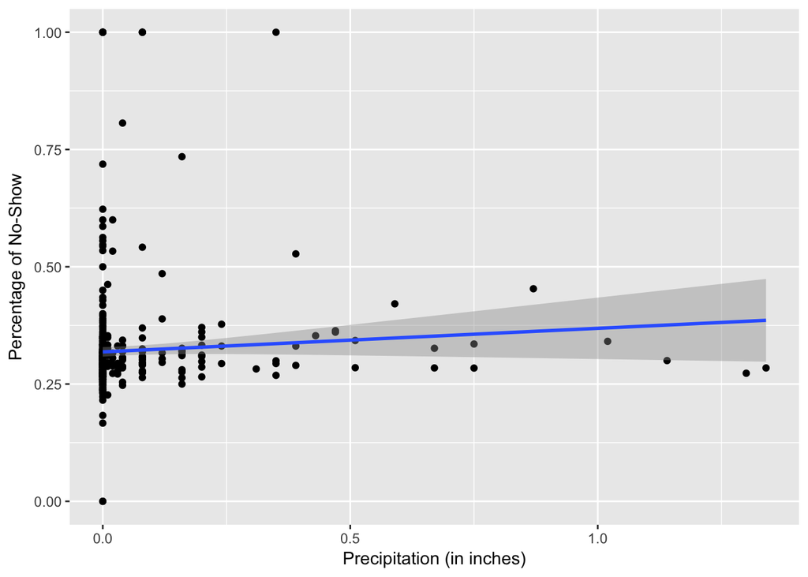

```r
by_temp <- group_by(dataset, appointment_date)
by_temp <- summarise(by_temp,
                     show = sum(show_up==1),
                     noshow = sum(show_up == 0),
                     max_temp = max(max_temp_faren),
                     lowest_visibility = max(as.numeric(lowest_visibility_miles)),
                     lowest_visibility = max(as.numeric(lowest_visibility_miles)),
                     wind = max(max_wind_mph),
                     max_precipitation_inches = max(precipitation_inches))
by_temp$ratio <- by_temp$noshow / (by_temp$show + by_temp$noshow)

qplot( max_precipitation_inches, ratio,
       data = by_temp[by_temp$max_precipitation_inches<2,],
       ylab = "Percentage of No-Show",
       xlab = "Precipitation (in inches)") +
  geom_smooth(show.legend = TRUE,method = 'lm')
```

```r
summary(lm(ratio~max_precipitation_inches,
           data = by_temp[by_temp$max_precipitation_inches<2,]))
```

```
##
## Call:
## lm(formula = ratio ~ max_precipitation_inches, data = by_temp[by_temp$max_precipitation_inches <
##     2, ])
##
## Residuals:
##      Min       1Q   Median       3Q      Max
## -0.31854 -0.04438 -0.02180  0.00055  0.68146
##
## Coefficients:
##                          Estimate Std. Error t value Pr(>|t|)
## (Intercept)              0.318544   0.005194  61.332   <2e-16 ***
## max_precipitation_inches 0.050223   0.034358   1.462    0.144
## ---
## Signif. codes:  0 '***' 0.001 '**' 0.01 '*' 0.05 '.' 0.1 ' ' 1
##
## Residual standard error: 0.1154 on 530 degrees of freedom
## Multiple R-squared:  0.004015,   Adjusted R-squared:  0.002136
## F-statistic: 2.137 on 1 and 530 DF,  p-value: 0.1444
```

Each point on the graph represent one day. We note that there is no correlation between the ratio and the precipitation level.

*Temperature*

[figure not shown]

```r
qplot(max_temp,
      ratio,
      data=by_temp,
      ylab="Temperature",
      xlab="Percentage of No-Show") +
  geom_smooth(show.legend=TRUE,
              method='lm')
```

```r
summary(lm(ratio ~ max_temp, data = by_temp))
```

```
##
## Call:
## lm(formula = ratio ~ max_temp, data = by_temp)
##
## Residuals:
##      Min       1Q   Median       3Q      Max
## -0.31642 -0.04249 -0.02391  0.00185  0.69016
##
## Coefficients:
##               Estimate Std. Error t value Pr(>|t|)
## (Intercept)  0.4309307  0.0733169   5.878 7.35e-09 ***
## max_temp    -0.0013162  0.0008726  -1.508    0.132
## ---
## Signif. codes:  0 '***' 0.001 '**' 0.01 '*' 0.05 '.' 0.1 ' ' 1
##
## Residual standard error: 0.1151 on 532 degrees of freedom
## Multiple R-squared:  0.004259,   Adjusted R-squared:  0.002387
## F-statistic: 2.275 on 1 and 532 DF,  p-value: 0.132
```

Same result with the temperature.

*Visibility*

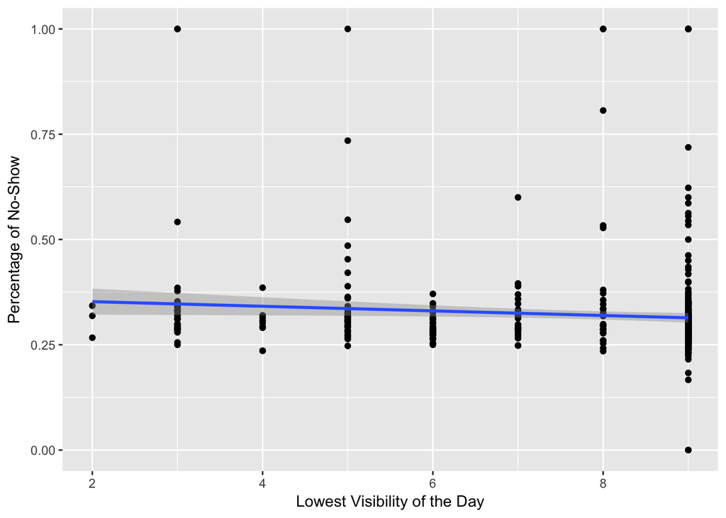

```r
qplot(lowest_visibility,
      ratio,
      data=by_temp,
      xlab="Lowest Visibility of the Day",
      ylab="Percentage of No-Show") +
  geom_smooth(show.legend=TRUE,
              method='lm')
```

```r
summary(lm(ratio ~ lowest_visibility, data = by_temp))
```

```
##
## Call:
## lm(formula = ratio ~ lowest_visibility, data = by_temp)
##
## Residuals:
##      Min       1Q   Median       3Q      Max
## -0.31402 -0.04358 -0.02190  0.00146  0.68598
##
## Coefficients:
##                    Estimate Std. Error t value Pr(>|t|)
## (Intercept)        0.363375   0.020717  17.540   <2e-16 ***
## lowest_visibility -0.005483   0.002578  -2.127   0.0339 *
## ---
## Signif. codes:  0 '***' 0.001 '**' 0.01 '*' 0.05 '.' 0.1 ' ' 1
##
## Residual standard error: 0.1149 on 532 degrees of freedom
## Multiple R-squared:  0.008433,   Adjusted R-squared:  0.00657
## F-statistic: 4.525 on 1 and 532 DF,  p-value: 0.03387
```

Visibility IS correlated with the ratio. We observe that the ratio decrease when the lowest visibility of the day increase. We obtain a good p-value of 3% for this correlation.

*Wind*

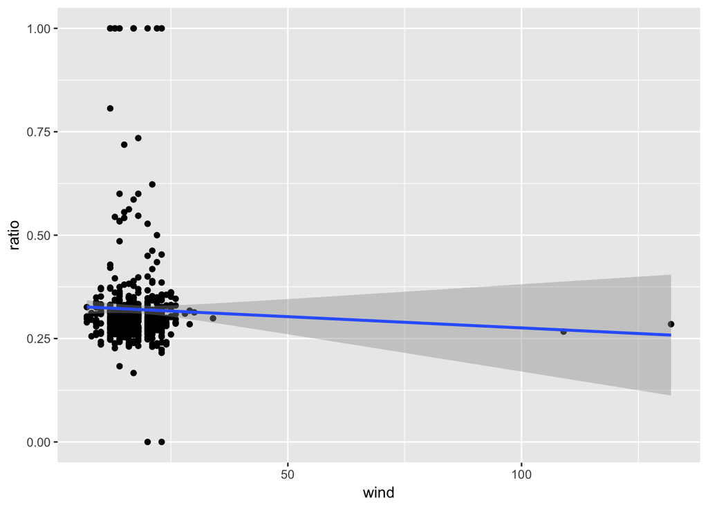

```r
qplot(wind,
      ratio,
      data=by_temp) +
  geom_smooth(show.legend=TRUE,
              method='lm')
```

```r
summary(lm(ratio ~ wind, data = by_temp))
```

```
##
## Call:
## lm(formula = ratio ~ wind, data = by_temp)
##
## Residuals:
##      Min       1Q   Median       3Q      Max
## -0.31920 -0.04426 -0.02205  0.00198  0.68243
##
## Coefficients:
##               Estimate Std. Error t value Pr(>|t|)
## (Intercept)  0.3300648  0.0123503  26.725   <2e-16 ***
## wind        -0.0005432  0.0006481  -0.838    0.402
## ---
## Signif. codes:  0 '***' 0.001 '**' 0.01 '*' 0.05 '.' 0.1 ' ' 1
##
## Residual standard error: 0.1153 on 532 degrees of freedom
## Multiple R-squared:  0.001319,   Adjusted R-squared:  -0.0005585
## F-statistic: 0.7025 on 1 and 532 DF,  p-value: 0.4023
```

Just like the two first variables, the wind speed is not correlated with the No-Sow ratio.

We conclude from this analysis that among all weather variables we found, the only feature that is a little bit correlated with the ratio is the lowest visibility of the day.